# Relatório de Consumo de Energia

Análise Estatística Descritiva em R

Author

Affiliation

Vinícius Rodrigues dos Santos

Faculdade SENAC DF, Professor Ken, Estatística

Published

02/05/2025

## 1 Introdução

Este relatório tem como objetivo analisar o consumo de energia da residência do **Vinícius Rodrigues dos Santos**. Para isso, identificaremos os moradores da casa e avaliaremos o consumo individual de cada um.

Além disso, faremos uma análise dos principais aparelhos que contribuem para o custo de energia, utilizando **estatística descritiva** para extrair informações relevantes. Para melhorar a interpretação dos dados, apresentaremos tabelas e gráficos que facilitarão a visualização dos padrões de consumo.

Ao final, desenvolveremos um **plano de ação** com estratégias para reduzir o consumo de energia e otimizar os gastos da residência.

Como forma de demonstrar **criatividade** este relatório será gerado utilizando o formato `.qmd` no **RStudio**, permitindo a criação de uma página **HTML** interativa e dinâmica. Dessa forma, buscamos facilitar a leitura e interpretação das informações, além de compartilhar conhecimento sobre a linguagem **R** e suas aplicações em análise de dados.

## 2 Moradores da casa

A casa analisada possui **4 moradores e 1 cachorro**. As pessoas que moram na casa são:

1. **Vinícius**
2. **Gustavo**
3. **Rosângela**
4. **Emerson**

## 3 Hábito de consumo de energia dos moradores

De uma forma geral, os hábitos de consumo de energia concentram-se no uso de aparelhos eletrônicos. Abaixo está o consumo conforme cada morador:

### 3.1 🔹 **Vinícius**

- Deixa o celular carregando durante toda a noite e, ao longo do dia, recarrega o fone sem fio por aproximadamente **2 horas**.
- Carrega o notebook ao menos uma vez por **1 hora**.
- Toma entre **2 e 3 banhos diários**, com duração média de **10 minutos**, gerando consumo no chuveiro e nas lâmpadas de LED à noite.
- Enquanto usa o notebook, mantém a **televisão ligada**.
- Em períodos de calor, utiliza um **ar-condicionado portátil** durante a noite.

### 3.2 🔹 **Gustavo**

- Carrega o celular **1 vez ao dia**.
- Toma **3 banhos diários**, com cerca de **10 minutos** de duração cada.
- Uma vez ao dia, recarrega o **fone sem fio por 1 hora**.
- Assiste cerca de **2 horas de televisão por dia**.
- Em dias quentes, utiliza um **ventilador** durante a noite.

### 3.3 🔹 **Rosângela**

- Carrega o celular durante a noite e mais **2 vezes ao longo do dia**.
- Recarrega um **fone sem fio por 2 horas diárias**.
- Assiste aproximadamente **3 horas de televisão por dia**.
- Toma **4 banhos diários**, cada um com cerca de **10 minutos**.
- Utiliza um **ar-condicionado** durante a noite em períodos de calor.
- Faz uso da **máquina de lavar roupas de segunda a sexta-feira**.

### 3.4 🔹 **Emerson**

- Carrega o celular **2 vezes ao dia**.
- Toma em média **2 banhos diários**, com duração de **5 minutos** cada.
- Assiste cerca de **1 hora de televisão por dia**.
- Utiliza uma **chaleira elétrica 3 vezes ao dia** para aquecer água.
- Usa uma **panela de pressão elétrica uma vez ao dia**.
- Em períodos de calor, recorre ao **ar-condicionado durante a noite**.

### 3.5 🔹 **Visitas**

- Além dos gastos de cada morador citado acima. Em média de 2 vezes por mês a casa recebe visita de avós e primos durante mais ou menos 3 dias (sexta-domingo). Fato esse que faz com que nesses períodos de visita o nível de consumo acaba aumentando.

## 4 Aparelhos que mais consomem energia

### 4.1 🔹 Os aparelhos da casa que mais consomem energia (não estão ordenados):

- **Ar-condicionado**
- **Ar-condicionado portátil**
- **Ventilador**
- **Geladeira**
- **Aparelho de internet**
- **Aparelho da televisão**
- **Televisão**
- **Máquina de lavar roupa**
- **Carregador de celular**
- **Lâmpadas**

## 5 Tabelas e Estatísticas

### 5.1 Análise da **tabela** de Consumo de Energia Elétrica (Abril 2024 - Abril 2025)

### 5.2 🔹 **Mês/Ano**

A coluna mês/ano apresenta o mês em que os dados analisados se referem.

### 5.3 🔹 **Variação do Consumo (KWH)**

O menor consumo foi registrado em **maio de 2024** (244 KWH), enquanto o maior ocorreu em **setembro de 2024** (352 KWH). Essas oscilações podem estar ligadas a fatores sazonais, como temperatura e hábitos de uso.

### 5.4 🔹 **Gastos com Energia**

O valor pago geralmente acompanha o consumo de energia, mas algumas discrepâncias foram observadas. Em **outubro de 2024**, o consumo foi de 262 KWH, mas o valor pago foi relativamente alto (**R$ 292,53**), sugerindo possíveis variações na tarifa ou cobranças adicionais.

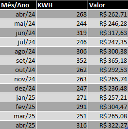

Tabela excel informações iniciais

**Ocultar/Mostrar Código**

```r
#CRIAÇÂO DA TABELA NO R
mes_ano <- c("abr/24", "mai/24", "jun/24", "jul/24", "ago/24", "set/24", "out/24", "nov/24",
             "dez/24", "jan/25", "fev/25", "mar/25", "abr/25")

kwh_utilizado <- c(268, 244, 319, 246, 306, 352, 262, 263, 247, 271, 291, 251, 316)

valor_conta <- c(262.71, 246.28, 317.63, 247.35, 300.38, 365.18, 292.53, 265.74,
                 236.48, 257.21, 304.47, 265.08, 322.27)

df_dados_energia <- data.frame(
  mes_ano = factor(mes_ano, levels = mes_ano, ordered = TRUE),
  kwh_utilizado,
  valor_conta
)
```

### 5.5 Análise da **tabela** de média, mediana e moda

- **Média**: O consumo médio de energia é de **280 KWH**, correspondendo a um custo médio de **R$ 283,33**.
- **Mediana**: O valor mediano de consumo é **268 KWH**, o que significa que metade dos registros estão abaixo desse valor e metade acima. O custo mediano é **R$ 265,74**.
- **Moda**: Não há uma moda, indicando que nenhum valor de consumo ou custo se repete com maior frequência no conjunto de dados.
- Esses dados são fundamentais para entender padrões de consumo e auxiliar na gestão financeira do uso de energia elétrica.

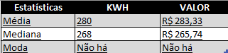

Tabela excel dados estatísticos

### 5.6 Média calculada no R

**Ocultar/Mostrar Código**

```r
#MEDIA CALCULADA NO R
media_kwh <- mean(kwh_utilizado)
media_valor <- mean(valor_conta)
cat("Média kwh:", media_kwh, "\n")
```

```
Média kwh: 279.6923
```

**Ocultar/Mostrar Código**

```r
cat("Média valor:", media_valor, "\n")
```

```
Média valor: 283.3315
```

### 5.7 Mediana calculada no R

**Ocultar/Mostrar Código**

```r
#MEDIANA CALCULADA NO R
mediana_kwh <- median(kwh_utilizado)
mediana_valor <- median(valor_conta)
cat("Mediana kwh:", mediana_kwh, "\n")
```

```
Mediana kwh: 268
```

**Ocultar/Mostrar Código**

```r
cat("Mediana valor:", mediana_valor, "\n")
```

```
Mediana valor: 265.74
```

### 5.8 Moda calculada no R

**Ocultar/Mostrar Código**

```r
#MODA CALCULADA NO R
calcular_moda <- function(x) {
  uniqx <- unique(x)
  freq <- tabulate(match(x, uniqx))
  max_freq <- max(freq)

  if (max_freq == 1) {
    return("Não há moda")
  } else {
    return(uniqx[which(freq == max_freq)])
  }
}


moda_kwh <- calcular_moda(kwh_utilizado)
moda_valor <- calcular_moda(valor_conta)
cat("Moda kwh:", moda_kwh, "\n")
```

```
Moda kwh: Não há moda
```

**Ocultar/Mostrar Código**

```r
cat("Moda valor:", moda_valor, "\n")
```

```
Moda valor: Não há moda
```

### 5.10 Desvio Padrão calculada no R

**Ocultar/Mostrar Código**

```r
#CALCULO DO DESVIO PADRÂO NO R
desvio_padrao_kwh <- sd(kwh_utilizado)
desvio_padrao_valor <- sd(valor_conta)
cat("Desvio padrão kwh:", desvio_padrao_kwh, "\n")
```

```
Desvio padrão kwh: 34.17695
```

**Ocultar/Mostrar Código**

```r
cat("Desvio padrão valor:", desvio_padrao_valor, "\n")
```

```
Desvio padrão valor: 37.44615
```

### 5.11 Máximo, Mínimo, Amplitude calculada no R

**Ocultar/Mostrar Código**

```r
#CALCULO DO MÁXIMO, MÍNIMO< AMPLITUDE
max_kwh <- max(kwh_utilizado)
min_kwh <- min(kwh_utilizado)

max_valor <- max(valor_conta)
min_valor <- min(valor_conta)

amplitude_kwh <- max_kwh - min_kwh
amplitude_valor <- max_valor - min_valor

cat("Max kwh:", max_kwh, "\n")
```

```
Max kwh: 352
```

**Ocultar/Mostrar Código**

```r
cat("Min kwh:", min_kwh, "\n")
```

```
Min kwh: 244
```

**Ocultar/Mostrar Código**

```r
cat("Max valor:", max_valor, "\n")
```

```
Max valor: 365.18
```

**Ocultar/Mostrar Código**

```r
cat("Min valor:", min_valor, "\n")
```

```
Min valor: 236.48
```

**Ocultar/Mostrar Código**

```r
cat("Amplitude kwh:", amplitude_kwh, "\n")
```

```
Amplitude kwh: 108
```

**Ocultar/Mostrar Código**

```r
cat("Amplitude valor:", amplitude_valor, "\n")
```

```
Amplitude valor: 128.7
```

### 5.12 Variância calculada no R

**Ocultar/Mostrar Código**

```r
variancia_kwh <- var(kwh_utilizado)
variancia_valor <- var(valor_conta)

cat("Variância kwh:", variancia_kwh, "\n")
```

```
Variância kwh: 1168.064
```

**Ocultar/Mostrar Código**

```r
cat("Variância valor:", variancia_valor, "\n")
```

```
Variância valor: 1402.214
```

### 5.13 Covariância calculada no R

**Ocultar/Mostrar Código**

```r
covariancia <- cov(kwh_utilizado, valor_conta)
cat("Covariância:", covariancia, "\n")
```

```
Covariância: 1213.08
```

### 5.14 Análise da **tabela** de dados trimestrais

- **Maior Consumo**: O trimestre de **Jul-Set** apresentou o maior consumo médio, atingindo **301 KWH**, com um custo médio de **R$ 304,30**.
- **Menor Consumo**: O trimestre de **Out-Dez** teve o menor consumo médio, com **257 KWH**, e um custo médio de **R$ 264,92**.
- **Variação dos Custos**: O consumo médio mais alto coincide com o maior custo médio, evidenciando uma relação direta entre o uso de energia e os gastos.
- A análise dos dados trimestrais revela padrões de variação no consumo de energia e nos custos associados. Essas informações podem ser utilizadas para planejamento financeiro e para estratégias de economia energética ao longo do ano.

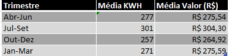

Tabela excel dados por trimestre

**Ocultar/Mostrar Código**

```r
#CRIAÇÂO DA TABELA DOS DADOS TRIMESTRAIS
trimestre <- c("Abr-Jun", "Jul-Set", "Out-Dez", "Jan-Mar")
media_kwh <- c(277, 301, 257, 271)
media_valor <- c(275.54, 304.30, 264.92, 275.59)

df_visao_por_trimestre <- data.frame(Trimestre = trimestre,
                           Media_KWH = media_kwh,
                           Media_Valor = media_valor)
print(df_visao_por_trimestre)
```

```
  Trimestre Media_KWH Media_Valor
1   Abr-Jun       277      275.54
2   Jul-Set       301      304.30
3   Out-Dez       257      264.92
4   Jan-Mar       271      275.59
```

### 5.15 Análise da **tabela** de variação percentual do consumo de energia

- **Variação Significativa**: Os meses de **junho de 2024** (+30,74%) e **abril de 2025** (+25,90%) apresentam os maiores aumentos no consumo de energia.
- **Queda Mais Expressiva**: O consumo registrou a maior redução em **outubro de 2024** (-25,57%) e **julho de 2024** (-22,88%).
- **Flutuação do Consumo**: O padrão de consumo varia significativamente ao longo do ano, sugerindo influências sazonais como clima, hábitos e demandas energéticas.
- A variação percentual no consumo de energia elétrica ao longo dos meses evidencia períodos de aumento e redução, o que pode ser útil para prever gastos futuros e implementar medidas de economia. A análise desses dados é essencial para uma gestão eficiente do consumo de energia.

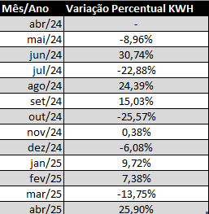

Tabela excel variação %

**Ocultar/Mostrar Código**

```r
#CRIAÇÃO DO DATA FRAME COM VARIAÇÃO PERCENTUAL DO CONSUMO
mes_ano <- c("abr/24", "mai/24", "jun/24", "jul/24", "ago/24", "set/24",
             "out/24", "nov/24", "dez/24", "jan/25", "fev/25", "mar/25", "abr/25")

variacao_percentual <- c(0, -8.96, 30.74, -22.88, 24.39, 15.03,
                         -25.57, 0.38, -6.08, 9.72, 7.38, -13.75, 25.90)

df_variacao_percentual <- data.frame(
  Mes_Ano = factor(mes_ano, levels = mes_ano, ordered = TRUE),
  Variacao_Percentual_KWH = variacao_percentual
)

print(df_variacao_percentual)
```

```
   Mes_Ano Variacao_Percentual_KWH
1   abr/24                    0.00
2   mai/24                   -8.96
3   jun/24                   30.74
4   jul/24                  -22.88
5   ago/24                   24.39
6   set/24                   15.03
7   out/24                  -25.57
8   nov/24                    0.38
9   dez/24                   -6.08
10  jan/25                    9.72
11  fev/25                    7.38
12  mar/25                  -13.75
13  abr/25                   25.90
```

### 5.16 Análise da **tabela** de distribuição da frequência de consumo

**Ocultar/Mostrar Código**

```r
#CRIAÇÃO DO DATA FRAME COM DISTRIBUIÇÃO DA FREQUÊNCIA DO CONSUMO
intervalo <- c("244 - 266", "267 - 289", "290 - 312", "313 - 335", "336 - 358")
frequencia <- c(6, 2, 2, 2, 1)

df_frequencia <- data.frame(Intervalo = intervalo, Frequencia = frequencia)

print(df_frequencia)
```

```
  Intervalo Frequencia
1 244 - 266          6
2 267 - 289          2
3 290 - 312          2
4 313 - 335          2
5 336 - 358          1
```

## 6 Gráficos

**Ocultar/Mostrar Código**

```r
#CARREGA BIBLIOTECAS PARA CRIAR OS GRÁFICOS
library(ggplot2)
library(scales)
library(tidyr)
```

### 6.1 Gráfico consumo mensal

**Ocultar/Mostrar Código**

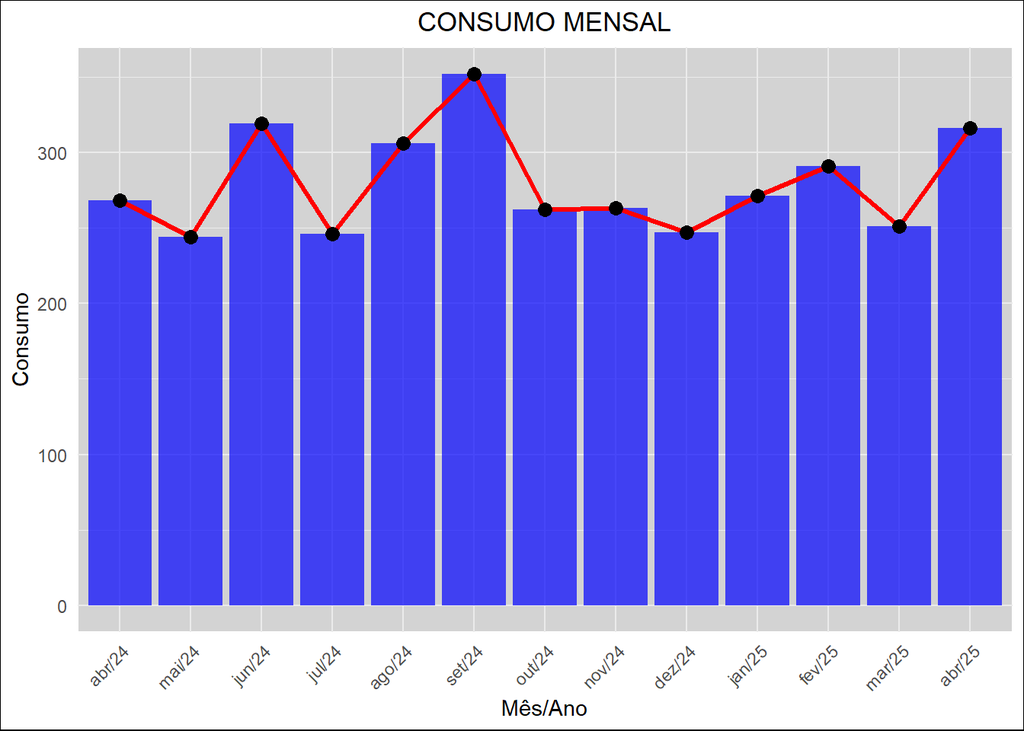

```r
ggplot(df_dados_energia, aes(x = mes_ano, y = kwh_utilizado)) +
  geom_bar(stat = "identity", fill = "blue", alpha = 0.7) +
  geom_line(aes(group = 1), color = "red", size = 1.2) +
  geom_point(color = "black", size = 3) +
  labs(title = "CONSUMO MENSAL",
       x = "Mês/Ano",
       y = "Consumo") +
  theme_minimal() +
  theme(
    plot.title = element_text(color = "black", hjust = 0.5),
    axis.text.x = element_text(angle = 45, hjust = 1),
    panel.background = element_rect(fill = "lightgray", color = "white"),
    plot.background = element_rect(fill = "white")
  )
```

### 6.2 Gráfico do valor mensal

**Ocultar/Mostrar Código**

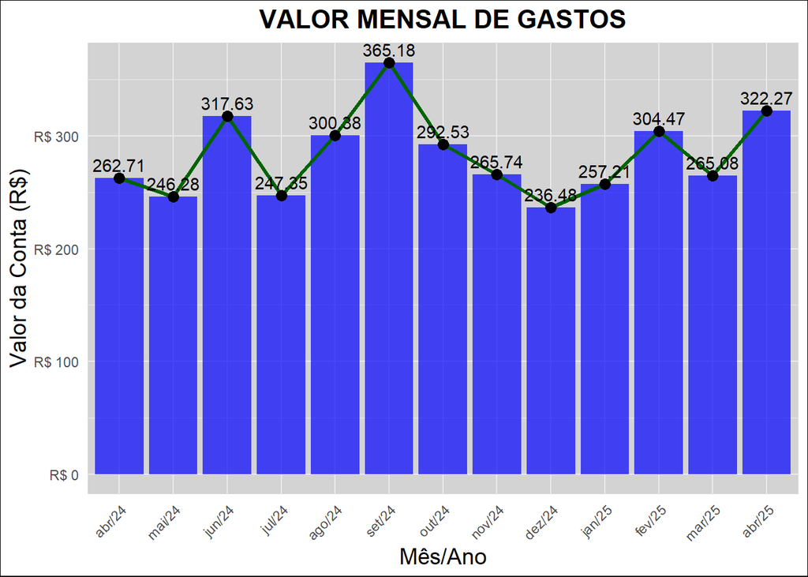

```r
ggplot(df_dados_energia, aes(x = mes_ano, y = valor_conta)) +
  geom_bar(stat = "identity", fill = "blue", alpha = 0.7) +
  geom_line(aes(group = 1), color = "darkgreen", size = 1.2) +
  geom_point(color = "black", size = 3) +
  geom_text(aes(label = round(valor_conta, 2)), vjust = -0.5, color = "black") +
  labs(title = "VALOR MENSAL DE GASTOS",
       x = "Mês/Ano",
       y = "Valor da Conta (R$)") +
  scale_y_continuous(labels = label_dollar(prefix = "R$ ", big.mark = ".", decimal.mark = ",")) +
  theme_minimal() +
  theme(
    plot.title = element_text(color = "black", hjust = 0.5, size = 16, face = "bold"),
    axis.text.x = element_text(angle = 45, hjust = 1),
    axis.title.x = element_text(color = "black", size = 14),
    axis.title.y = element_text(color = "black", size = 14),
    panel.background = element_rect(fill = "lightgray", color = "white"),
    plot.background = element_rect(fill = "white")
  )
```

### 6.3 Gráfico das variações percentuais

- **Aumento Mais Significativo**: O maior aumento percentual ocorreu em **junho de 2024** (+30,74%), seguido por **abril de 2025** (+25,90%).
- **Maior Redução**: O consumo apresentou a maior queda em **outubro de 2024** (-25,57%), sugerindo um período de menor demanda energética.
- **Flutuações**: A análise indica uma variação expressiva ao longo do ano, possivelmente devido a fatores sazonais como clima e hábitos de consumo.
- O gráfico revela padrões importantes na variação percentual do consumo de energia elétrica, permitindo prever períodos de maior e menor demanda. Essas informações são essenciais para um planejamento energético eficiente e estratégias de economia.

**Ocultar/Mostrar Código**

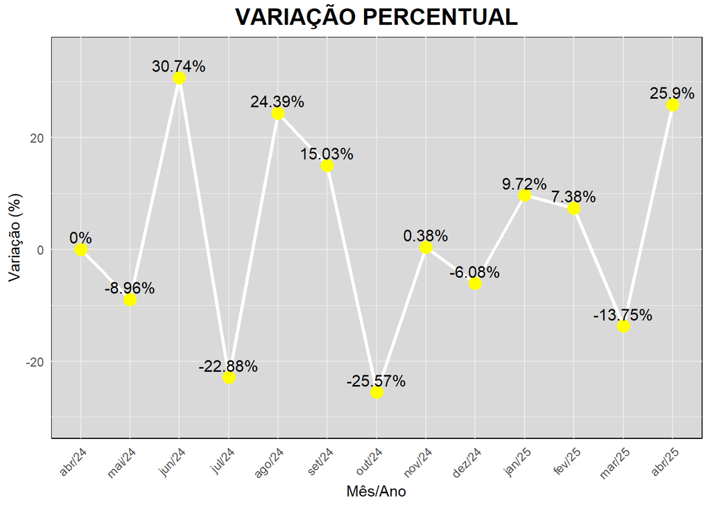

```r
ggplot(df_variacao_percentual, aes(x = Mes_Ano, y = Variacao_Percentual_KWH, group = 1)) +
  geom_line(color = "white", size = 1.2) +
  geom_point(color = "yellow", size = 4) +
  geom_text(aes(label = paste0(Variacao_Percentual_KWH, "%")),
            vjust = -0.5, size = 4, color = "black") +
  labs(title = "VARIAÇÃO PERCENTUAL",
       x = "Mês/Ano",
       y = "Variação (%)") +
  scale_y_continuous(limits = c(min(df_variacao_percentual$Variacao_Percentual_KWH) - 5,
                                max(df_variacao_percentual$Variacao_Percentual_KWH) + 4)) +
  theme_minimal() +
  theme(
    panel.background = element_rect(fill = "#D9D9D9", color = "black"),
    plot.title = element_text(hjust = 0.5, size = 16, face = "bold"),
    axis.text.x = element_text(angle = 45, hjust = 1)
  )
```

### 6.4 Gráfico consumo e custo por trimestre

- **Trimestre de Maior Consumo**: **Jul-Set** apresentou o maior consumo médio (**301 KWH**), acompanhado do maior custo médio (**R$ 304,30**).
- **Trimestre de Menor Consumo**: **Out-Dez** teve o menor consumo médio (**257 KWH**), refletindo um custo mais baixo (**R$ 264,92**).
- **Variação de Custos**: A relação entre consumo e custo segue um padrão consistente, indicando que períodos de maior demanda resultam em maior gasto.
- **Tendência de Consumo**: O gráfico sugere uma possível influência sazonal, com picos e quedas que podem estar relacionados a fatores externos como temperatura e hábitos de consumo.
- A análise do consumo e custo médio de energia por trimestre revela variações importantes ao longo do ano. Essas informações podem ser utilizadas para prever gastos futuros, ajustar estratégias de economia e otimizar o uso de energia elétrica.

**Ocultar/Mostrar Código**

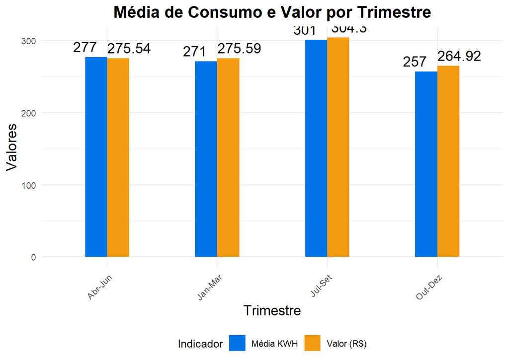

```r
dados_long <- pivot_longer(df_visao_por_trimestre, cols = c("Media_KWH", "Media_Valor"),
                           names_to = "Indicador", values_to = "Valor")
ggplot(dados_long, aes(x = Trimestre, y = Valor, fill = Indicador)) +
  geom_bar(stat = "identity", position = position_dodge(width = 0.4), width = 0.4) +
  geom_text(aes(label = round(Valor, 2)), position = position_dodge(width = 0.8), vjust = -0.5, size = 5, color = "black") +
  labs(title = "Média de Consumo e Valor por Trimestre",
       x = "Trimestre",
       y = "Valores") +
  scale_fill_manual(name = "Indicador",
                    labels = c("Média KWH", "Valor (R$)"),
                    values = c("#0073e6", "#f39c12")) +
  theme_minimal() +
  theme(plot.title = element_text(hjust = 0.5, size = 16, face = "bold"),
        axis.title.x = element_text(size = 14),
        axis.title.y = element_text(size = 14),
        axis.text.x = element_text(angle = 45, hjust = 1),
        legend.position = "bottom")
```

### 6.5 Gráfico de frequência de uso por intervalo

**Ocultar/Mostrar Código**

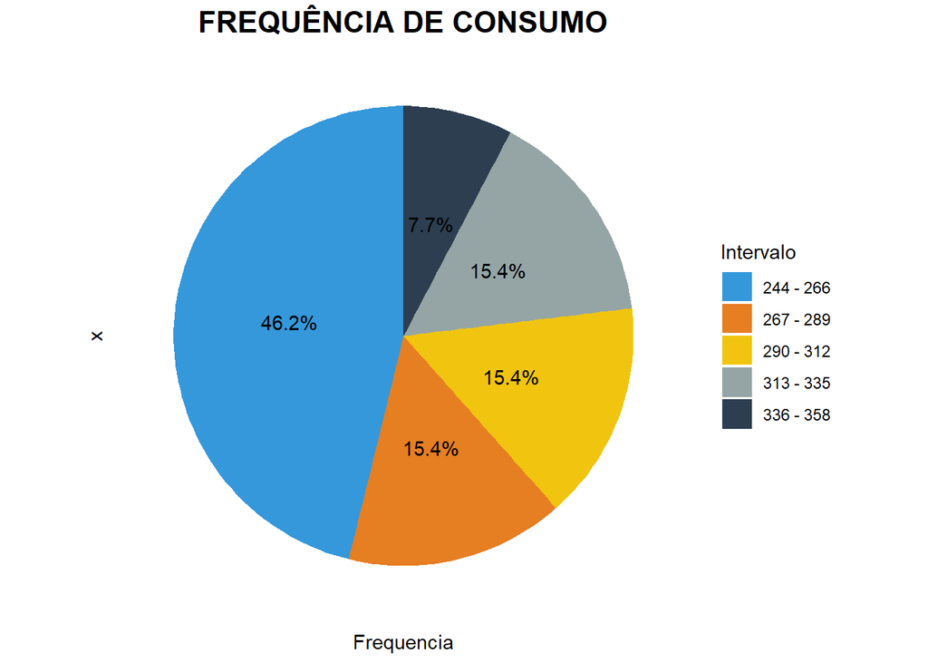

```r
ggplot(df_frequencia, aes(x = "", y = Frequencia, fill = Intervalo)) +
  geom_bar(stat = "identity", width = 1) +
  coord_polar("y", start = 0) +
  geom_text(aes(label = paste0(round(Frequencia / sum(Frequencia) * 100, 1), "%")),
            position = position_stack(vjust = 0.5)) +
  scale_fill_manual(values = c("#3498db", "#e67e22", "#f1c40f", "#95a5a6", "#2c3e50")) +
  labs(title = "FREQUÊNCIA DE CONSUMO") +
  theme_minimal() +
  theme(
    plot.title = element_text(hjust = 0.5, size = 16, face = "bold"),
    axis.text.x = element_blank(),
    axis.text.y = element_blank(),
    panel.grid = element_blank()
    )
```

## 7 Plano de Ação para Redução do Consumo

### 7.1 1. Mudança nos Hábitos de Consumo

- **Carregamento de dispositivos**: Indicar aos moradores que carreguem os celulares apenas até a carga completa, evitando a conexão desnecessária durante toda a noite.
- **Uso da televisão**: Não utilizar a televisão como fundo sonoro, ligar apenas quando for assistir de fato.
- **Banhos mais eficientes**: Reduzir o tempo de banho para que as médias fiquem abaixo de 10 minutos e, se possível, utilizar temperaturas mais baixas para diminuir o gasto do chuveiro.
- **Uso do notebook**: Ajustar o brilho da tela para que a bateria dure mais tempo e reduzir o tempo de carregamento.

### 7.2 2. Otimização de Aparelhos Eletrônicos

- **Ar-condicionado e ventilação**: Incentivar o uso da ventilação natural e limitar o uso de ar-condicionado e ventiladores a dias de calor extremo.
- **Iluminação**: Trocar todas as lâmpadas para LED e lembrar sempre de apagá-las quando o uso não for necessário.
- **Eletrodomésticos**: Reduzir a frequência de abertura da geladeira e utilizar a máquina de lavar apenas quando houver uma quantidade maior de roupas para lavar.

### 7.3 3. Redução de Consumo em Dias de Visitas

- **Monitoramento do consumo**: Incentivar as visitas a adotarem práticas sustentáveis, como redução do tempo de banho e utilização moderada de aparelhos eletrônicos.
- **Uso compartilhado de eletrônicos**: Evitar o uso simultâneo de televisões e outros dispositivos.

### 7.4 4. Conscientização

- **Reuniões periódicas**: Conversar com os moradores e as visitas sobre a importância e benefícios da economia de energia.
- **Monitoramento**: Acompanhar mensalmente ou trimestralmente as médias de consumo para identificar o que precisa ser melhorado.